# Risk Factor Analysis

## Outcome Variable

**Outcome Variable:** wast_rec90d

## Predictor Variables

**Intervention Variable:** impsan

**Adjustment Set:**

- arm
- sex
- W_mage
- meducyrs
- feducyrs
- hhwealth_quart
- hfoodsec
- W_mhtcm
- W_mwtkg
- W_mbmi
- W_nrooms
- W_nchldlt5
- W_parity
- impfloor
- safeh20
- delta_W_mage
- delta_meducyrs
- delta_feducyrs
- delta_hhwealth_quart
- delta_hfoodsec
- delta_W_mhtcm
- delta_W_mwtkg
- delta_W_mbmi
- delta_W_nrooms
- delta_W_nchldlt5
- delta_W_parity
- delta_impfloor
- delta_safeh20

## Stratifying Variables

The analysis was stratified on these variable(s):

- agecat
- studyid
- country

## Data Summary

| agecat | studyid | country | impsan | wast_rec90d | n_cell | n |
| --- | --- | --- | --- | --- | --- | --- |
| 0-24 months | ki0047075b-MAL-ED | BANGLADESH | 1 | 0 | 33 | 121 |
| 0-24 months | ki0047075b-MAL-ED | BANGLADESH | 1 | 1 | 67 | 121 |
| 0-24 months | ki0047075b-MAL-ED | BANGLADESH | 0 | 0 | 10 | 121 |
| 0-24 months | ki0047075b-MAL-ED | BANGLADESH | 0 | 1 | 11 | 121 |
| 0-24 months | ki0047075b-MAL-ED | BRAZIL | 1 | 0 | 6 | 24 |
| 0-24 months | ki0047075b-MAL-ED | BRAZIL | 1 | 1 | 17 | 24 |
| 0-24 months | ki0047075b-MAL-ED | BRAZIL | 0 | 0 | 0 | 24 |
| 0-24 months | ki0047075b-MAL-ED | BRAZIL | 0 | 1 | 1 | 24 |
| 0-24 months | ki0047075b-MAL-ED | INDIA | 1 | 0 | 25 | 172 |
| 0-24 months | ki0047075b-MAL-ED | INDIA | 1 | 1 | 43 | 172 |
| 0-24 months | ki0047075b-MAL-ED | INDIA | 0 | 0 | 39 | 172 |
| 0-24 months | ki0047075b-MAL-ED | INDIA | 0 | 1 | 65 | 172 |
| 0-24 months | ki0047075b-MAL-ED | NEPAL | 1 | 0 | 19 | 97 |
| 0-24 months | ki0047075b-MAL-ED | NEPAL | 1 | 1 | 78 | 97 |
| 0-24 months | ki0047075b-MAL-ED | NEPAL | 0 | 0 | 0 | 97 |
| 0-24 months | ki0047075b-MAL-ED | NEPAL | 0 | 1 | 0 | 97 |
| 0-24 months | ki0047075b-MAL-ED | PERU | 1 | 0 | 3 | 33 |
| 0-24 months | ki0047075b-MAL-ED | PERU | 1 | 1 | 6 | 33 |
| 0-24 months | ki0047075b-MAL-ED | PERU | 0 | 0 | 3 | 33 |
| 0-24 months | ki0047075b-MAL-ED | PERU | 0 | 1 | 21 | 33 |
| 0-24 months | ki0047075b-MAL-ED | SOUTH AFRICA | 1 | 0 | 1 | 79 |
| 0-24 months | ki0047075b-MAL-ED | SOUTH AFRICA | 1 | 1 | 1 | 79 |
| 0-24 months | ki0047075b-MAL-ED | SOUTH AFRICA | 0 | 0 | 12 | 79 |
| 0-24 months | ki0047075b-MAL-ED | SOUTH AFRICA | 0 | 1 | 65 | 79 |
| 0-24 months | ki0047075b-MAL-ED | TANZANIA, UNITED REPUBLIC OF | 1 | 0 | 0 | 50 |
| 0-24 months | ki0047075b-MAL-ED | TANZANIA, UNITED REPUBLIC OF | 1 | 1 | 0 | 50 |
| 0-24 months | ki0047075b-MAL-ED | TANZANIA, UNITED REPUBLIC OF | 0 | 0 | 9 | 50 |
| 0-24 months | ki0047075b-MAL-ED | TANZANIA, UNITED REPUBLIC OF | 0 | 1 | 41 | 50 |
| 0-24 months | ki1017093-NIH-Birth | BANGLADESH | 1 | 0 | 66 | 421 |
| 0-24 months | ki1017093-NIH-Birth | BANGLADESH | 1 | 1 | 81 | 421 |

[output cut: 174 more lines]

The following strata were considered:

- agecat: 0-24 months, studyid: ki0047075b-MAL-ED, country: BANGLADESH
- agecat: 0-24 months, studyid: ki0047075b-MAL-ED, country: BRAZIL
- agecat: 0-24 months, studyid: ki0047075b-MAL-ED, country: INDIA
- agecat: 0-24 months, studyid: ki0047075b-MAL-ED, country: NEPAL
- agecat: 0-24 months, studyid: ki0047075b-MAL-ED, country: PERU
- agecat: 0-24 months, studyid: ki0047075b-MAL-ED, country: SOUTH AFRICA
- agecat: 0-24 months, studyid: ki0047075b-MAL-ED, country: TANZANIA, UNITED REPUBLIC OF
- agecat: 0-24 months, studyid: ki1017093-NIH-Birth, country: BANGLADESH
- agecat: 0-24 months, studyid: ki1017093b-PROVIDE, country: BANGLADESH
- agecat: 0-24 months, studyid: ki1017093c-NIH-Crypto, country: BANGLADESH
- agecat: 0-24 months, studyid: ki1114097-CONTENT, country: PERU
- agecat: 0-24 months, studyid: ki1135781-COHORTS, country: GUATEMALA
- agecat: 0-24 months, studyid: ki1135781-COHORTS, country: INDIA
- agecat: 0-24 months, studyid: ki1135781-COHORTS, country: PHILIPPINES
- agecat: 0-24 months, studyid: ki1148112-LCNI-5, country: MALAWI
- agecat: 0-24 months, studyid: kiGH5241-JiVitA-3, country: BANGLADESH
- agecat: 0-24 months, studyid: kiGH5241-JiVitA-4, country: BANGLADESH
- agecat: 0-6 months, studyid: ki0047075b-MAL-ED, country: BANGLADESH
- agecat: 0-6 months, studyid: ki0047075b-MAL-ED, country: BRAZIL
- agecat: 0-6 months, studyid: ki0047075b-MAL-ED, country: INDIA
- agecat: 0-6 months, studyid: ki0047075b-MAL-ED, country: NEPAL
- agecat: 0-6 months, studyid: ki0047075b-MAL-ED, country: PERU
- agecat: 0-6 months, studyid: ki0047075b-MAL-ED, country: SOUTH AFRICA
- agecat: 0-6 months, studyid: ki0047075b-MAL-ED, country: TANZANIA, UNITED REPUBLIC OF
- agecat: 0-6 months, studyid: ki1017093-NIH-Birth, country: BANGLADESH
- agecat: 0-6 months, studyid: ki1017093b-PROVIDE, country: BANGLADESH
- agecat: 0-6 months, studyid: ki1017093c-NIH-Crypto, country: BANGLADESH
- agecat: 0-6 months, studyid: ki1114097-CONTENT, country: PERU
- agecat: 0-6 months, studyid: ki1135781-COHORTS, country: GUATEMALA
- agecat: 0-6 months, studyid: ki1135781-COHORTS, country: INDIA
- agecat: 0-6 months, studyid: ki1135781-COHORTS, country: PHILIPPINES
- agecat: 0-6 months, studyid: ki1148112-LCNI-5, country: MALAWI
- agecat: 0-6 months, studyid: kiGH5241-JiVitA-3, country: BANGLADESH
- agecat: 0-6 months, studyid: kiGH5241-JiVitA-4, country: BANGLADESH
- agecat: 6-24 months, studyid: ki0047075b-MAL-ED, country: BANGLADESH
- agecat: 6-24 months, studyid: ki0047075b-MAL-ED, country: BRAZIL
- agecat: 6-24 months, studyid: ki0047075b-MAL-ED, country: INDIA
- agecat: 6-24 months, studyid: ki0047075b-MAL-ED, country: NEPAL
- agecat: 6-24 months, studyid: ki0047075b-MAL-ED, country: PERU
- agecat: 6-24 months, studyid: ki0047075b-MAL-ED, country: SOUTH AFRICA
- agecat: 6-24 months, studyid: ki0047075b-MAL-ED, country: TANZANIA, UNITED REPUBLIC OF
- agecat: 6-24 months, studyid: ki1017093-NIH-Birth, country: BANGLADESH
- agecat: 6-24 months, studyid: ki1017093b-PROVIDE, country: BANGLADESH
- agecat: 6-24 months, studyid: ki1017093c-NIH-Crypto, country: BANGLADESH
- agecat: 6-24 months, studyid: ki1114097-CONTENT, country: PERU
- agecat: 6-24 months, studyid: ki1135781-COHORTS, country: GUATEMALA
- agecat: 6-24 months, studyid: ki1135781-COHORTS, country: INDIA
- agecat: 6-24 months, studyid: ki1135781-COHORTS, country: PHILIPPINES
- agecat: 6-24 months, studyid: ki1148112-LCNI-5, country: MALAWI
- agecat: 6-24 months, studyid: kiGH5241-JiVitA-3, country: BANGLADESH
- agecat: 6-24 months, studyid: kiGH5241-JiVitA-4, country: BANGLADESH

### Dropped Strata

Some strata were dropped due to rare outcomes:

- agecat: 0-24 months, studyid: ki0047075b-MAL-ED, country: BRAZIL
- agecat: 0-24 months, studyid: ki0047075b-MAL-ED, country: NEPAL
- agecat: 0-24 months, studyid: ki0047075b-MAL-ED, country: PERU
- agecat: 0-24 months, studyid: ki0047075b-MAL-ED, country: SOUTH AFRICA
- agecat: 0-24 months, studyid: ki0047075b-MAL-ED, country: TANZANIA, UNITED REPUBLIC OF
- agecat: 0-24 months, studyid: ki1017093b-PROVIDE, country: BANGLADESH
- agecat: 0-24 months, studyid: ki1114097-CONTENT, country: PERU
- agecat: 0-24 months, studyid: ki1148112-LCNI-5, country: MALAWI
- agecat: 0-6 months, studyid: ki0047075b-MAL-ED, country: BANGLADESH
- agecat: 0-6 months, studyid: ki0047075b-MAL-ED, country: BRAZIL
- agecat: 0-6 months, studyid: ki0047075b-MAL-ED, country: NEPAL
- agecat: 0-6 months, studyid: ki0047075b-MAL-ED, country: PERU
- agecat: 0-6 months, studyid: ki0047075b-MAL-ED, country: SOUTH AFRICA
- agecat: 0-6 months, studyid: ki0047075b-MAL-ED, country: TANZANIA, UNITED REPUBLIC OF
- agecat: 0-6 months, studyid: ki1017093b-PROVIDE, country: BANGLADESH
- agecat: 0-6 months, studyid: ki1017093c-NIH-Crypto, country: BANGLADESH
- agecat: 0-6 months, studyid: ki1114097-CONTENT, country: PERU
- agecat: 0-6 months, studyid: ki1135781-COHORTS, country: GUATEMALA
- agecat: 0-6 months, studyid: ki1148112-LCNI-5, country: MALAWI
- agecat: 6-24 months, studyid: ki0047075b-MAL-ED, country: BANGLADESH
- agecat: 6-24 months, studyid: ki0047075b-MAL-ED, country: BRAZIL
- agecat: 6-24 months, studyid: ki0047075b-MAL-ED, country: NEPAL
- agecat: 6-24 months, studyid: ki0047075b-MAL-ED, country: PERU
- agecat: 6-24 months, studyid: ki0047075b-MAL-ED, country: SOUTH AFRICA
- agecat: 6-24 months, studyid: ki0047075b-MAL-ED, country: TANZANIA, UNITED REPUBLIC OF
- agecat: 6-24 months, studyid: ki1017093b-PROVIDE, country: BANGLADESH
- agecat: 6-24 months, studyid: ki1017093c-NIH-Crypto, country: BANGLADESH
- agecat: 6-24 months, studyid: ki1114097-CONTENT, country: PERU
- agecat: 6-24 months, studyid: ki1135781-COHORTS, country: GUATEMALA
- agecat: 6-24 months, studyid: ki1135781-COHORTS, country: INDIA
- agecat: 6-24 months, studyid: ki1148112-LCNI-5, country: MALAWI
- agecat: 6-24 months, studyid: kiGH5241-JiVitA-3, country: BANGLADESH

## Methods Detail

We’re interested in the causal parameters $E[Y_a]$ for all values of $a \in \mathcal{A}$. These parameters represent the mean outcome if, possibly contrary to fact, we intervened to set all units to have $A=a$. Under the randomization and positivity assumptions, these are identified by the statistical parameters $\psi_a=E_W[E_{Y|A,W}(Y|A=a,W)]$. In addition, we’re interested in the mean of $Y$, $E[Y]$ under no intervention (the observed mean). We will estimate these parameters by using SuperLearner to fit the relevant likelihood factors – $E_{Y|A,W}(Y|A=a,W)$ and $p(A=a|W)$, and then updating our likelihood fit using a joint TMLE.

For unadjusted analyses ($W=\{\}$), initial likelihoods were estimated using Lrnr_glm to estimate the simple $E(Y|A)$ and Lrnr_mean to estimate $p(A)$. For adjusted analyses, a small library containing Lrnr_glmnet, Lrnr_xgboost, and Lrnr_mean was used.

Having estimated these parameters, we will then use the delta method to estimate relative risks and attributable risks relative to a prespecified baseline level of $A$.

# Results Detail

## Results Plots

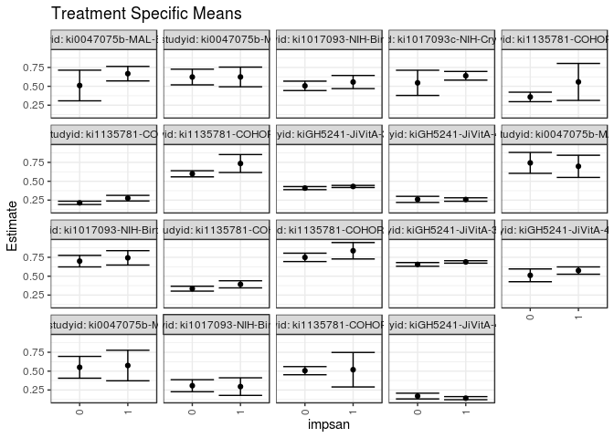

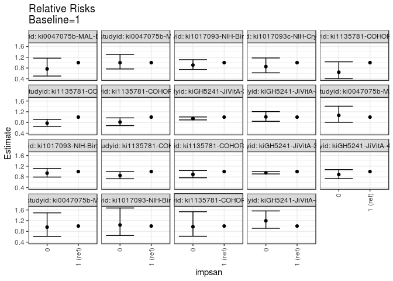

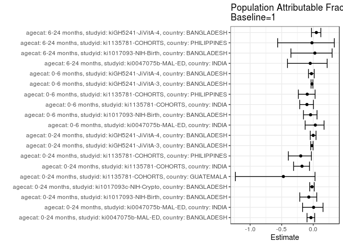

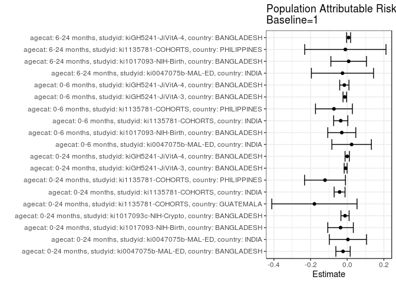

## Results Table

### Parameter: TSM

| agecat | studyid | country | intervention_level | baseline_level | estimate | ci_lower | ci_upper |
| --- | --- | --- | --- | --- | --- | --- | --- |
| 0-24 months | ki0047075b-MAL-ED | BANGLADESH | 1 | NA | 0.6675964 | 0.5714309 | 0.7637618 |
| 0-24 months | ki0047075b-MAL-ED | BANGLADESH | 0 | NA | 0.5106413 | 0.3078742 | 0.7134083 |
| 0-24 months | ki0047075b-MAL-ED | INDIA | 1 | NA | 0.6240063 | 0.4936723 | 0.7543403 |
| 0-24 months | ki0047075b-MAL-ED | INDIA | 0 | NA | 0.6230182 | 0.5192516 | 0.7267848 |
| 0-24 months | ki1017093-NIH-Birth | BANGLADESH | 1 | NA | 0.5566162 | 0.4697712 | 0.6434612 |
| 0-24 months | ki1017093-NIH-Birth | BANGLADESH | 0 | NA | 0.5061582 | 0.4439656 | 0.5683509 |
| 0-24 months | ki1017093c-NIH-Crypto | BANGLADESH | 1 | NA | 0.6394668 | 0.5819762 | 0.6969573 |
| 0-24 months | ki1017093c-NIH-Crypto | BANGLADESH | 0 | NA | 0.5458127 | 0.3789290 | 0.7126964 |
| 0-24 months | ki1135781-COHORTS | GUATEMALA | 1 | NA | 0.5579021 | 0.3131131 | 0.8026911 |
| 0-24 months | ki1135781-COHORTS | GUATEMALA | 0 | NA | 0.3590878 | 0.2962972 | 0.4218784 |
| 0-24 months | ki1135781-COHORTS | INDIA | 1 | NA | 0.2761364 | 0.2390127 | 0.3132601 |
| 0-24 months | ki1135781-COHORTS | INDIA | 0 | NA | 0.2138995 | 0.1921543 | 0.2356448 |
| 0-24 months | ki1135781-COHORTS | PHILIPPINES | 1 | NA | 0.7348446 | 0.6161450 | 0.8535442 |
| 0-24 months | ki1135781-COHORTS | PHILIPPINES | 0 | NA | 0.5988715 | 0.5584160 | 0.6393270 |
| 0-24 months | kiGH5241-JiVitA-3 | BANGLADESH | 1 | NA | 0.4311682 | 0.4173134 | 0.4450230 |
| 0-24 months | kiGH5241-JiVitA-3 | BANGLADESH | 0 | NA | 0.4092262 | 0.3889978 | 0.4294546 |
| 0-24 months | kiGH5241-JiVitA-4 | BANGLADESH | 1 | NA | 0.2580310 | 0.2350797 | 0.2809823 |
| 0-24 months | kiGH5241-JiVitA-4 | BANGLADESH | 0 | NA | 0.2600638 | 0.2197929 | 0.3003347 |
| 0-6 months | ki0047075b-MAL-ED | INDIA | 1 | NA | 0.6975421 | 0.5508679 | 0.8442162 |
| 0-6 months | ki0047075b-MAL-ED | INDIA | 0 | NA | 0.7430819 | 0.6044999 | 0.8816639 |
| 0-6 months | ki1017093-NIH-Birth | BANGLADESH | 1 | NA | 0.7427721 | 0.6474480 | 0.8380961 |
| 0-6 months | ki1017093-NIH-Birth | BANGLADESH | 0 | NA | 0.6991920 | 0.6228428 | 0.7755411 |
| 0-6 months | ki1135781-COHORTS | INDIA | 1 | NA | 0.3920710 | 0.3447661 | 0.4393760 |
| 0-6 months | ki1135781-COHORTS | INDIA | 0 | NA | 0.3347067 | 0.3024123 | 0.3670011 |
| 0-6 months | ki1135781-COHORTS | PHILIPPINES | 1 | NA | 0.8367347 | 0.7280039 | 0.9454655 |
| 0-6 months | ki1135781-COHORTS | PHILIPPINES | 0 | NA | 0.7489177 | 0.6935154 | 0.8043201 |
| 0-6 months | kiGH5241-JiVitA-3 | BANGLADESH | 1 | NA | 0.6886486 | 0.6723211 | 0.7049762 |
| 0-6 months | kiGH5241-JiVitA-3 | BANGLADESH | 0 | NA | 0.6560597 | 0.6317476 | 0.6803719 |
| 0-6 months | kiGH5241-JiVitA-4 | BANGLADESH | 1 | NA | 0.5741685 | 0.5257720 | 0.6225649 |
| 0-6 months | kiGH5241-JiVitA-4 | BANGLADESH | 0 | NA | 0.5113421 | 0.4267288 | 0.5959554 |
| 6-24 months | ki0047075b-MAL-ED | INDIA | 1 | NA | 0.5742885 | 0.3721229 | 0.7764542 |
| 6-24 months | ki0047075b-MAL-ED | INDIA | 0 | NA | 0.5506832 | 0.4063231 | 0.6950432 |
| 6-24 months | ki1017093-NIH-Birth | BANGLADESH | 1 | NA | 0.2950978 | 0.1784752 | 0.4117205 |
| 6-24 months | ki1017093-NIH-Birth | BANGLADESH | 0 | NA | 0.3068023 | 0.2269500 | 0.3866546 |
| 6-24 months | ki1135781-COHORTS | PHILIPPINES | 1 | NA | 0.5189244 | 0.2903397 | 0.7475091 |
| 6-24 months | ki1135781-COHORTS | PHILIPPINES | 0 | NA | 0.5056623 | 0.4516484 | 0.5596761 |
| 6-24 months | kiGH5241-JiVitA-4 | BANGLADESH | 1 | NA | 0.1418447 | 0.1212618 | 0.1624277 |
| 6-24 months | kiGH5241-JiVitA-4 | BANGLADESH | 0 | NA | 0.1696663 | 0.1316775 | 0.2076551 |

### Parameter: E(Y)

| agecat | studyid | country | intervention_level | baseline_level | estimate | ci_lower | ci_upper |
| --- | --- | --- | --- | --- | --- | --- | --- |
| 0-24 months | ki0047075b-MAL-ED | BANGLADESH | NA | NA | 0.6446281 | 0.5577732 | 0.7314830 |
| 0-24 months | ki0047075b-MAL-ED | INDIA | NA | NA | 0.6279070 | 0.5477344 | 0.7080796 |
| 0-24 months | ki1017093-NIH-Birth | BANGLADESH | NA | NA | 0.5201900 | 0.4695846 | 0.5707955 |
| 0-24 months | ki1017093c-NIH-Crypto | BANGLADESH | NA | NA | 0.6274510 | 0.5732906 | 0.6816113 |
| 0-24 months | ki1135781-COHORTS | GUATEMALA | NA | NA | 0.3787879 | 0.3179432 | 0.4396325 |
| 0-24 months | ki1135781-COHORTS | INDIA | NA | NA | 0.2344546 | 0.2156201 | 0.2532892 |
| 0-24 months | ki1135781-COHORTS | PHILIPPINES | NA | NA | 0.6134700 | 0.5751620 | 0.6517779 |
| 0-24 months | kiGH5241-JiVitA-3 | BANGLADESH | NA | NA | 0.4224868 | 0.4113573 | 0.4336163 |
| 0-24 months | kiGH5241-JiVitA-4 | BANGLADESH | NA | NA | 0.2580019 | 0.2386523 | 0.2773515 |
| 0-6 months | ki0047075b-MAL-ED | INDIA | NA | NA | 0.7215190 | 0.6193314 | 0.8237066 |
| 0-6 months | ki1017093-NIH-Birth | BANGLADESH | NA | NA | 0.7130045 | 0.6535890 | 0.7724200 |
| 0-6 months | ki1135781-COHORTS | INDIA | NA | NA | 0.3565891 | 0.3304405 | 0.3827378 |
| 0-6 months | ki1135781-COHORTS | PHILIPPINES | NA | NA | 0.7642857 | 0.7146210 | 0.8139505 |
| 0-6 months | kiGH5241-JiVitA-3 | BANGLADESH | NA | NA | 0.6755499 | 0.6622049 | 0.6888949 |
| 0-6 months | kiGH5241-JiVitA-4 | BANGLADESH | NA | NA | 0.5583942 | 0.5167799 | 0.6000084 |
| 6-24 months | ki0047075b-MAL-ED | INDIA | NA | NA | 0.5483871 | 0.4327976 | 0.6639766 |
| 6-24 months | ki1017093-NIH-Birth | BANGLADESH | NA | NA | 0.3030303 | 0.2377927 | 0.3682679 |
| 6-24 months | ki1135781-COHORTS | PHILIPPINES | NA | NA | 0.5086849 | 0.4571562 | 0.5602135 |
| 6-24 months | kiGH5241-JiVitA-4 | BANGLADESH | NA | NA | 0.1492734 | 0.1316631 | 0.1668838 |

### Parameter: RR

| agecat | studyid | country | intervention_level | baseline_level | estimate | ci_lower | ci_upper |
| --- | --- | --- | --- | --- | --- | --- | --- |
| 0-24 months | ki0047075b-MAL-ED | BANGLADESH | 1 | 1 | 1.0000000 | 1.0000000 | 1.0000000 |
| 0-24 months | ki0047075b-MAL-ED | BANGLADESH | 0 | 1 | 0.7648952 | 0.5013042 | 1.1670851 |
| 0-24 months | ki0047075b-MAL-ED | INDIA | 1 | 1 | 1.0000000 | 1.0000000 | 1.0000000 |
| 0-24 months | ki0047075b-MAL-ED | INDIA | 0 | 1 | 0.9984165 | 0.7639220 | 1.3048918 |
| 0-24 months | ki1017093-NIH-Birth | BANGLADESH | 1 | 1 | 1.0000000 | 1.0000000 | 1.0000000 |
| 0-24 months | ki1017093-NIH-Birth | BANGLADESH | 0 | 1 | 0.9093487 | 0.7451912 | 1.1096685 |
| 0-24 months | ki1017093c-NIH-Crypto | BANGLADESH | 1 | 1 | 1.0000000 | 1.0000000 | 1.0000000 |
| 0-24 months | ki1017093c-NIH-Crypto | BANGLADESH | 0 | 1 | 0.8535435 | 0.6207697 | 1.1736018 |
| 0-24 months | ki1135781-COHORTS | GUATEMALA | 1 | 1 | 1.0000000 | 1.0000000 | 1.0000000 |
| 0-24 months | ki1135781-COHORTS | GUATEMALA | 0 | 1 | 0.6436395 | 0.4016144 | 1.0315161 |
| 0-24 months | ki1135781-COHORTS | INDIA | 1 | 1 | 1.0000000 | 1.0000000 | 1.0000000 |
| 0-24 months | ki1135781-COHORTS | INDIA | 0 | 1 | 0.7746156 | 0.6545329 | 0.9167290 |
| 0-24 months | ki1135781-COHORTS | PHILIPPINES | 1 | 1 | 1.0000000 | 1.0000000 | 1.0000000 |
| 0-24 months | ki1135781-COHORTS | PHILIPPINES | 0 | 1 | 0.8149635 | 0.6838213 | 0.9712559 |
| 0-24 months | kiGH5241-JiVitA-3 | BANGLADESH | 1 | 1 | 1.0000000 | 1.0000000 | 1.0000000 |
| 0-24 months | kiGH5241-JiVitA-3 | BANGLADESH | 0 | 1 | 0.9491105 | 0.8951587 | 1.0063139 |
| 0-24 months | kiGH5241-JiVitA-4 | BANGLADESH | 1 | 1 | 1.0000000 | 1.0000000 | 1.0000000 |
| 0-24 months | kiGH5241-JiVitA-4 | BANGLADESH | 0 | 1 | 1.0078781 | 0.8430297 | 1.2049615 |
| 0-6 months | ki0047075b-MAL-ED | INDIA | 1 | 1 | 1.0000000 | 1.0000000 | 1.0000000 |
| 0-6 months | ki0047075b-MAL-ED | INDIA | 0 | 1 | 1.0652862 | 0.8075170 | 1.4053384 |
| 0-6 months | ki1017093-NIH-Birth | BANGLADESH | 1 | 1 | 1.0000000 | 1.0000000 | 1.0000000 |
| 0-6 months | ki1017093-NIH-Birth | BANGLADESH | 0 | 1 | 0.9413277 | 0.7951054 | 1.1144408 |
| 0-6 months | ki1135781-COHORTS | INDIA | 1 | 1 | 1.0000000 | 1.0000000 | 1.0000000 |
| 0-6 months | ki1135781-COHORTS | INDIA | 0 | 1 | 0.8536891 | 0.7315747 | 0.9961868 |
| 0-6 months | ki1135781-COHORTS | PHILIPPINES | 1 | 1 | 1.0000000 | 1.0000000 | 1.0000000 |
| 0-6 months | ki1135781-COHORTS | PHILIPPINES | 0 | 1 | 0.8950480 | 0.7707387 | 1.0394068 |
| 0-6 months | kiGH5241-JiVitA-3 | BANGLADESH | 1 | 1 | 1.0000000 | 1.0000000 | 1.0000000 |
| 0-6 months | kiGH5241-JiVitA-3 | BANGLADESH | 0 | 1 | 0.9526770 | 0.9120249 | 0.9951411 |
| 0-6 months | kiGH5241-JiVitA-4 | BANGLADESH | 1 | 1 | 1.0000000 | 1.0000000 | 1.0000000 |
| 0-6 months | kiGH5241-JiVitA-4 | BANGLADESH | 0 | 1 | 0.8905785 | 0.7396356 | 1.0723254 |
| 6-24 months | ki0047075b-MAL-ED | INDIA | 1 | 1 | 1.0000000 | 1.0000000 | 1.0000000 |
| 6-24 months | ki0047075b-MAL-ED | INDIA | 0 | 1 | 0.9588963 | 0.6167729 | 1.4907955 |
| 6-24 months | ki1017093-NIH-Birth | BANGLADESH | 1 | 1 | 1.0000000 | 1.0000000 | 1.0000000 |
| 6-24 months | ki1017093-NIH-Birth | BANGLADESH | 0 | 1 | 1.0396629 | 0.6467629 | 1.6712445 |
| 6-24 months | ki1135781-COHORTS | PHILIPPINES | 1 | 1 | 1.0000000 | 1.0000000 | 1.0000000 |
| 6-24 months | ki1135781-COHORTS | PHILIPPINES | 0 | 1 | 0.9744430 | 0.6191905 | 1.5335170 |
| 6-24 months | kiGH5241-JiVitA-4 | BANGLADESH | 1 | 1 | 1.0000000 | 1.0000000 | 1.0000000 |
| 6-24 months | kiGH5241-JiVitA-4 | BANGLADESH | 0 | 1 | 1.1961406 | 0.9159408 | 1.5620578 |

### Parameter: PAR

| agecat | studyid | country | intervention_level | baseline_level | estimate | ci_lower | ci_upper |
| --- | --- | --- | --- | --- | --- | --- | --- |
| 0-24 months | ki0047075b-MAL-ED | BANGLADESH | 1 | NA | -0.0229683 | -0.0620892 | 0.0161526 |
| 0-24 months | ki0047075b-MAL-ED | INDIA | 1 | NA | 0.0039007 | -0.0975569 | 0.1053582 |
| 0-24 months | ki1017093-NIH-Birth | BANGLADESH | 1 | NA | -0.0364262 | -0.1061434 | 0.0332911 |
| 0-24 months | ki1017093c-NIH-Crypto | BANGLADESH | 1 | NA | -0.0120158 | -0.0344062 | 0.0103746 |
| 0-24 months | ki1135781-COHORTS | GUATEMALA | 1 | NA | -0.1791142 | -0.4117441 | 0.0535157 |
| 0-24 months | ki1135781-COHORTS | INDIA | 1 | NA | -0.0416818 | -0.0714228 | -0.0119407 |
| 0-24 months | ki1135781-COHORTS | PHILIPPINES | 1 | NA | -0.1213746 | -0.2328973 | -0.0098519 |
| 0-24 months | kiGH5241-JiVitA-3 | BANGLADESH | 1 | NA | -0.0086814 | -0.0165831 | -0.0007797 |
| 0-24 months | kiGH5241-JiVitA-4 | BANGLADESH | 1 | NA | -0.0000290 | -0.0118421 | 0.0117840 |
| 0-6 months | ki0047075b-MAL-ED | INDIA | 1 | NA | 0.0239769 | -0.0838749 | 0.1318288 |
| 0-6 months | ki1017093-NIH-Birth | BANGLADESH | 1 | NA | -0.0297676 | -0.1062841 | 0.0467489 |
| 0-6 months | ki1135781-COHORTS | INDIA | 1 | NA | -0.0354819 | -0.0741533 | 0.0031896 |
| 0-6 months | ki1135781-COHORTS | PHILIPPINES | 1 | NA | -0.0724490 | -0.1732018 | 0.0283039 |
| 0-6 months | kiGH5241-JiVitA-3 | BANGLADESH | 1 | NA | -0.0130987 | -0.0228505 | -0.0033470 |
| 0-6 months | kiGH5241-JiVitA-4 | BANGLADESH | 1 | NA | -0.0157743 | -0.0409884 | 0.0094397 |
| 6-24 months | ki0047075b-MAL-ED | INDIA | 1 | NA | -0.0259014 | -0.1954849 | 0.1436821 |
| 6-24 months | ki1017093-NIH-Birth | BANGLADESH | 1 | NA | 0.0079325 | -0.0892102 | 0.1050751 |
| 6-24 months | ki1135781-COHORTS | PHILIPPINES | 1 | NA | -0.0102395 | -0.2320338 | 0.2115547 |
| 6-24 months | kiGH5241-JiVitA-4 | BANGLADESH | 1 | NA | 0.0074287 | -0.0035598 | 0.0184172 |

### Parameter: PAF

| agecat | studyid | country | intervention_level | baseline_level | estimate | ci_lower | ci_upper |
| --- | --- | --- | --- | --- | --- | --- | --- |
| 0-24 months | ki0047075b-MAL-ED | BANGLADESH | 1 | NA | -0.0356302 | -0.0982024 | 0.0233768 |
| 0-24 months | ki0047075b-MAL-ED | INDIA | 1 | NA | 0.0062122 | -0.1692634 | 0.1553536 |
| 0-24 months | ki1017093-NIH-Birth | BANGLADESH | 1 | NA | -0.0700247 | -0.2128665 | 0.0559943 |
| 0-24 months | ki1017093c-NIH-Crypto | BANGLADESH | 1 | NA | -0.0191502 | -0.0555979 | 0.0160390 |
| 0-24 months | ki1135781-COHORTS | GUATEMALA | 1 | NA | -0.4728615 | -1.2334272 | 0.0287031 |
| 0-24 months | ki1135781-COHORTS | INDIA | 1 | NA | -0.1777817 | -0.3106367 | -0.0583939 |
| 0-24 months | ki1135781-COHORTS | PHILIPPINES | 1 | NA | -0.1978493 | -0.3943365 | -0.0290507 |
| 0-24 months | kiGH5241-JiVitA-3 | BANGLADESH | 1 | NA | -0.0205483 | -0.0394138 | -0.0020253 |
| 0-24 months | kiGH5241-JiVitA-4 | BANGLADESH | 1 | NA | -0.0001125 | -0.0469632 | 0.0446416 |
| 0-6 months | ki0047075b-MAL-ED | INDIA | 1 | NA | 0.0332312 | -0.1283697 | 0.1716882 |
| 0-6 months | ki1017093-NIH-Birth | BANGLADESH | 1 | NA | -0.0417495 | -0.1549764 | 0.0603773 |
| 0-6 months | ki1135781-COHORTS | INDIA | 1 | NA | -0.0995035 | -0.2135182 | 0.0037992 |
| 0-6 months | ki1135781-COHORTS | PHILIPPINES | 1 | NA | -0.0947931 | -0.2355973 | 0.0299657 |
| 0-6 months | kiGH5241-JiVitA-3 | BANGLADESH | 1 | NA | -0.0193897 | -0.0339427 | -0.0050416 |
| 0-6 months | kiGH5241-JiVitA-4 | BANGLADESH | 1 | NA | -0.0282495 | -0.0744879 | 0.0159992 |
| 6-24 months | ki0047075b-MAL-ED | INDIA | 1 | NA | -0.0472320 | -0.4076183 | 0.2208862 |
| 6-24 months | ki1017093-NIH-Birth | BANGLADESH | 1 | NA | 0.0261772 | -0.3534690 | 0.2993331 |
| 6-24 months | ki1135781-COHORTS | PHILIPPINES | 1 | NA | -0.0201295 | -0.5640997 | 0.3346562 |
| 6-24 months | kiGH5241-JiVitA-4 | BANGLADESH | 1 | NA | 0.0497657 | -0.0269088 | 0.1207153 |